# First-class Beta (continuous-proportion) support in bayesTLS

Author

Daniel W.A. Noble

Published

May 21, 2026

## The problem

`bayesTLS` was built around **count** TDT data: every fit is `n_surv | trials(n_total) ~ <4PL>` with a `binomial`/`beta_binomial` family, `standardize_data()` requires an `n_total` denominator, and the prediction-grid builder `new_tdt_grid()` hard-codes `as.integer(round(median(data$n_total)))`.

Piet’s snow-gum leaf PSII case study (`notes/2026-05-20-bayesian-tdt-leaves.qmd`, and the leaf section of `ms/supplement.qmd`) is **not** count data. The response is a continuous proportion — the ratio $F_\mathrm{v}/F_\mathrm{m}^{\,\text{after}} / F_\mathrm{v}/F_\mathrm{m}^{\,\text{before}}$ — bounded in $[0,1]$ with **no denominator**. The natural likelihood is `brms::Beta()`, and the response term is `y ~ <4PL>` (no `trials()`).

Because the package has no Beta path, the leaf workflow currently:

1. bypasses `standardize_data()` (hand-built `mutate()`),
2. shadows the package `make_4pl_formula()` with a locally-inlined beta-capable copy (carrying a `response_var` argument the package version lacks), and
3. hand-builds the `bayes_tls` workflow with `structure()`.

Even so it **crashes downstream**: `predict_survival_curves()`, `derive_tdt_curve()`, `derive_temperature_for_duration()` and `extract_tdt()` all route through `new_tdt_grid()`, whose `median(data$n_total)` errors with *“non-numeric argument to mathematical function”* when there is no `n_total` column (`median(NULL)` returns `NULL`; `round(NULL)` throws). `derive_tdt_landscape()` and `predict_heat_injury()` build their own grids and already work.

This note records the decision to add Beta as a **first-class** response family and validates the one open modelling choice (the link function) before any code enters `R/`.

## Decisions

1. **Scope — full first-class Beta.** Generalise `standardize_data()`, `make_4pl_formula()`, `fit_4pl()`, `make_4pl_priors()`, `new_tdt_grid()` and `summarise_observed_survival()` so a continuous proportion is fit through the *same* pipeline as counts. The leaf section then calls `standardize_data(proportion = ...)` → `fit_4pl(family = brms::Beta(...))` with no inlined overrides and no hand-built workflow.
2. **Link — `Beta(link = "identity")`, validated here.** Consistent with the existing `beta_binomial(link = "identity")` decision (`notes/2026-05-12-identity-vs-logit-link.qmd`). Safe **because** the disjoint-bounds reparameterisation ($\text{low} = 0.001 + \mathrm{invlogit}(\text{lowraw})\cdot 0.498$, $\text{up} = 0.501 + \mathrm{invlogit}(\text{upraw})\cdot 0.498$) keeps the 4PL mean strictly inside $(0,1)$ *before* the link, so the Beta density never sees an illegal mean. Piet’s prototype used `link = "logit"` with `y ~ logit(p)`; the simulation below confirms the two are indistinguishable.
3. **Leaf zeros — clamped Beta, documented limitation.** The leaf data carry a genuine point mass at zero (see below). We keep the squeeze to $[0.001, 0.999]$ and a plain Beta likelihood (matching the current supplement), and flag in the manuscript that ~19% of leaf observations are structural zeros that a zero-inflated Beta would model more faithfully. This is a deliberate simplicity-vs-fidelity trade-off, not an oversight.

## Why the leaf zeros are a real modelling caveat

```r
suppressMessages(library(dplyr))
leaf <- readr::read_csv(here::here("data", "data_function_PSII_TDT_snowgum.csv"),
                        show_col_types = FALSE)
p <- leaf$final_fvfm / leaf$initial_fvfm
tibble::tibble(
  n              = sum(!is.na(p)),
  exact_zero     = sum(p <= 0, na.rm = TRUE),
  pct_zero       = round(100 * mean(p <= 0, na.rm = TRUE), 1),
  reaches_one    = any(p >= 1, na.rm = TRUE),
  max_p          = round(max(p, na.rm = TRUE), 3)
)
```

```
# A tibble: 1 × 5
      n exact_zero pct_zero reaches_one max_p
  <int>      <int>    <dbl> <lgl>       <dbl>
1   319         60     18.8 FALSE        0.96
```

60 of 319 leaf observations (19%) are **exactly 0** — complete PSII shutdown (dead/denatured tissue), concentrated at high dose — and none reach 1. The Beta likelihood has zero density at exactly 0/1, so these must be handled. The literature (Smithson & Verkuilen 2006; brms `zero_one_inflated_beta`) treats a *frequent, structural* boundary mass with a zero-inflated model and a *rare nuisance* boundary with the squeeze $(y(n-1)+0.5)/n$ or a small clamp. At 19% the principled choice is zero-inflated Beta; we have chosen the clamp for pipeline uniformity and will state the limitation.

## brms facts the design relies on (verified)

- **`posterior_linpred(transform = TRUE)` needs no `trials`/`n_total`.** It returns the inverse-link of the linear predictor — the per-trial mean probability — for `binomial`/`beta_binomial`, and the mean for `Beta`. Only `posterior_epred`/`posterior_predict` need `trials`, and only for count families. So guarding `n_total` in `new_tdt_grid()` is safe for every family. (brms `posterior_epred.R`, `posterior_linpred.brmsfit`.)
- **`phi` parameterisation/prior (brms 2.23.0, checked empirically).** Both `Beta()` and `beta_binomial()` carry a precision parameter `phi` with prior `class = "phi"`, bounded `<lower = 0>` (natural scale; default `gamma(0.01, 0.01)`). So the package’s `make_4pl_priors(prior_phi = "gamma(2, 0.1)")` is applied on the natural scale and works unchanged for both families. `fit_4pl()` only needs its family check extended so it also sets the `phi` prior when `family$family == "beta"`.
- **Identity link safety is conditional on the reparam.** Identity on Beta is only safe while the predictor is guaranteed in $(0,1)$. Document the dependency so a future change that drops the `inv_logit` clamp doesn’t silently break sampling.

## Inventory: what changes vs what is already family-agnostic

**CHANGE / GUARD (6 functions):**

| Function | File | Action |
| --- | --- | --- |
| `standardize_data()` | `R/standardize_data.R` | add `proportion =` path; make `n_total` optional; record `response_type` in `tdt_meta` |
| `make_4pl_formula()` | `R/fit_4pl.R` | add `response_var`; branch Beta → `y ~ <4PL>` (no `trials`); keep count default byte-identical |
| `fit_4pl()` | `R/fit_4pl.R` | infer `response_type`/`response_var`; default family from it; set `phi` prior for Beta; record family in `meta` |
| `make_4pl_priors()` | `R/priors.R` | already emits `class="phi"`; no change beyond docs (verified) |
| `new_tdt_grid()` | `R/predict_survival_curves.R` | only fill `n_total` for count families / when column present |
| `summarise_observed_survival()` | `R/predict_survival_curves.R` | skip `n_total_sum` when absent |

## Implementation plan (ordered)

1. `standardize_data()`: add `proportion = NULL` (mutually exclusive with the count specs), `proportion_eps = 0.001`. Proportion path stores `survival` = raw proportion (for overlays) and a clamped response column; sets `response_type = "proportion"` in `tdt_meta`; `n_total` becomes optional.
2. `make_4pl_formula(..., response_var = NULL)`: Beta family → `<response_var> ~ <main_rhs>` (+ `phi ~ 1`); else the existing `n_surv | trials(n_total) ~ <main_rhs>`. Default behaviour unchanged.
3. `fit_4pl()`: read `response_type` from `meta`; default `family` (beta_binomial for counts, Beta for proportions); pass `response_var`; set `phi` prior for Beta as well as beta_binomial; store `family`/`response_type` in `meta`.
4. `new_tdt_grid()` + `summarise_observed_survival()`: guard `n_total`.
5. Reinstall; fast tests (formula construction, standardize proportion path); confirm the leaf workflow runs end-to-end through the general API.
6. Rewrite the supplement leaf section + `notes/2026-05-20-bayesian-tdt-leaves.qmd` to the general API (identity link); reinstall; re-render; verify.

## Validation: `Beta(link = "identity")` vs `Beta(link = "logit")`

We validate on a single **leaf-like** scenario — the actual use case: a survival curve with asymptotes near 0/1 sampled over its full dynamic range, with a slug of exact zeros at high dose (clamped, per our policy). Two questions:

1. **Link.** Does `Beta(link = "identity")` give the same fit as `Beta(link = "logit")` (Piet’s reference)? Controlled contrast: same data, same priors, same sampler — only the link changes.
2. **Recovery through the package.** Do the *new* `standardize_data(proportion =)` → `fit_4pl(family = Beta())` functions recover the known truth, and do the downstream helpers that used to assume `n_total` now run?

We report the **slope $\beta_1$ on `mid`** as the recovery target, not $z = -1/\beta_1$ directly: near $\beta_1 = 0$ the reciprocal explodes, so $\beta_1$ is the robust quantity to compare (its sign and magnitude are what identify $z$).

> **Interior-asymptote data (not shown here).** A separate regime — proportions whose asymptotes sit well *inside* $(0,1)$ (e.g. high-baseline sublethal data) — is **not** the leaf case (leaf goes to ~0) and is **family-agnostic**: it was already covered for `beta_binomial` in `notes/2026-05-12-identity-vs-logit-link.qmd`. One caveat surfaced while building this note and is worth recording: `make_4pl_priors()` centres the asymptote priors at `lower + 0.02·range` and `lower + 0.98·range`, i.e. it *assumes asymptotes near the edges of `[lower, upper]`*. For genuinely interior asymptotes the user must set `lower`/`upper` to bracket them (as the package docs state) or broaden the asymptote priors; otherwise the informative defaults bias `low`/`up` toward the edges and `z` becomes weakly identified. This is independent of the link and of the Beta vs beta-binomial choice.

```r
suppressMessages({
  library(dplyr); library(brms); library(ggplot2); library(bayesTLS)
})
set.seed(20260521)
models_dir <- here::here("output", "models", "beta_link_test")
if (!dir.exists(models_dir)) dir.create(models_dir, recursive = TRUE)

# Disjoint-bounds reparam (lower = 0, upper = 1), matching compute_4pl_bounds().
low_min <- 0.001; low_w <- 0.498
up_min  <- 0.501; up_w  <- 0.498
main_rhs <- paste0(
  "(", low_min, " + inv_logit(lowraw) * ", low_w, ") + ",
  "((", up_min, " + inv_logit(upraw) * ", up_w, ") - ",
  "(", low_min, " + inv_logit(lowraw) * ", low_w, ")) / ",
  "(1 + exp(exp(logk) * (logd - mid)))"
)
# phi left as a default (constant) dpar, matching the count path.
f_identity <- bf(stats::as.formula(paste("y_beta ~", main_rhs)),
                 lowraw ~ temp_c, upraw ~ temp_c, logk ~ temp_c, mid ~ temp_c,
                 nl = TRUE, family = brms::Beta(link = "identity"))
f_logit    <- bf(stats::as.formula(paste("y_beta ~ logit(", main_rhs, ")")),
                 lowraw ~ temp_c, upraw ~ temp_c, logk ~ temp_c, mid ~ temp_c,
                 nl = TRUE, family = brms::Beta(link = "logit"))
```

```r
# Leaf-like truth: low ~ 0, up ~ 1, full dynamic range; durations bracket the
# midpoint so the slope is identified. p(T,t) = low + (up-low)/(1+exp(k*(logd-mid(T)))).
Tbar <- 33; beta1_true <- -0.18; z_true <- -1 / beta1_true
k_true <- 6; mid0_true <- log10(30); low_true <- 0.05; up_true <- 0.95; phi <- 15

dat <- expand.grid(temp = c(30, 33, 36),
                   duration = c(5, 15, 30, 60, 120), rep = 1:10)
dat$temp_c <- dat$temp - Tbar
dat$logd   <- log10(dat$duration)
mid_T      <- mid0_true + beta1_true * dat$temp_c
p_true     <- low_true + (up_true - low_true) /
              (1 + exp(k_true * (dat$logd - mid_T)))
p_true     <- pmin(pmax(p_true, 1e-6), 1 - 1e-6)
dat$y_prop <- stats::rbeta(nrow(dat), p_true * phi, (1 - p_true) * phi)
# Inject leaf-like exact zeros at the hottest x longest cells (dead tissue).
hot <- which(dat$temp == 36 & dat$duration >= 60)
dat$y_prop[sample(hot, 10)] <- 0
dat$y_beta <- pmin(pmax(dat$y_prop, 0.001), 0.999)   # clamp policy

c(z_true = round(z_true, 2),
  exact_zeros = sum(dat$y_prop <= 0),
  clamped = sum(dat$y_prop != dat$y_beta))
```

```
     z_true exact_zeros     clamped
       5.56       10.00       13.00
```

```r
pr <- make_4pl_priors(data = dat, lower = 0, upper = 1, prior_phi = NULL)
```

```r
fit_one <- function(formula, tag) {
  brms::brm(formula = formula, data = dat, prior = pr,
            chains = 3, iter = 2000, warmup = 1000, cores = 3,
            seed = 123, init = 0, backend = "cmdstanr",
            control = list(adapt_delta = 0.97, max_treedepth = 12),
            refresh = 0, file = file.path(models_dir, tag),
            file_refit = "on_change")
}
f_id <- fit_one(f_identity, "leaf_identity")
f_lg <- fit_one(f_logit,    "leaf_logit")
```

```r
inv_logit <- function(x) 1 / (1 + exp(-x))
summ_one <- function(fit, tag) {
  np  <- brms::nuts_params(fit)
  d   <- as.data.frame(fit, variable = c("b_mid_temp_c", "b_lowraw_Intercept",
                                          "b_upraw_Intercept"))
  b1  <- d$b_mid_temp_c
  tibble::tibble(
    model       = tag,
    divergences = sum(np$Value[np$Parameter == "divergent__"]),
    rhat_max    = round(max(brms::rhat(fit), na.rm = TRUE), 4),
    beta1       = round(stats::median(b1), 3),
    beta1_lwr   = round(stats::quantile(b1, .025), 3),
    beta1_upr   = round(stats::quantile(b1, .975), 3),
    low         = round(stats::median(0.001 + inv_logit(d$b_lowraw_Intercept) * 0.498), 3),
    up          = round(stats::median(0.501 + inv_logit(d$b_upraw_Intercept) * 0.498), 3)
  )
}
dplyr::bind_rows(summ_one(f_id, "identity"), summ_one(f_lg, "logit")) |>
  dplyr::mutate(beta1_true = beta1_true, low_true = low_true, up_true = up_true)
```

```
# A tibble: 2 × 11
  model   divergences rhat_max  beta1 beta1_lwr beta1_upr   low    up beta1_true
  <chr>         <dbl>    <dbl>  <dbl>     <dbl>     <dbl> <dbl> <dbl>      <dbl>
1 identi…           0     1.00 -0.182    -0.196    -0.167 0.046 0.961      -0.18
2 logit             0     1.00 -0.182    -0.196    -0.166 0.046 0.961      -0.18
# ℹ 2 more variables: low_true <dbl>, up_true <dbl>
```

```r
# Implied posterior-mean survival curves on a shared grid: identity vs logit.
pred_curve <- function(fit) {
  nd <- expand.grid(temp = c(30, 33, 36),
                    duration = 10^seq(log10(3), log10(200), length.out = 80))
  nd$temp_c <- nd$temp - Tbar
  nd$logd   <- log10(nd$duration)
  nd$p_med  <- apply(brms::posterior_linpred(fit, newdata = nd, re_formula = NA,
                                             transform = TRUE, ndraws = 600),
                     2, median)
  nd
}
a <- pred_curve(f_id); b <- pred_curve(f_lg)
d <- abs(a$p_med - b$p_med)
tibble::tibble(max_abs_diff = round(max(d), 5),
               rmse         = round(sqrt(mean(d^2)), 5))
```

```
# A tibble: 1 × 2
  max_abs_diff   rmse
         <dbl>  <dbl>
1      0.00586 0.0015
```

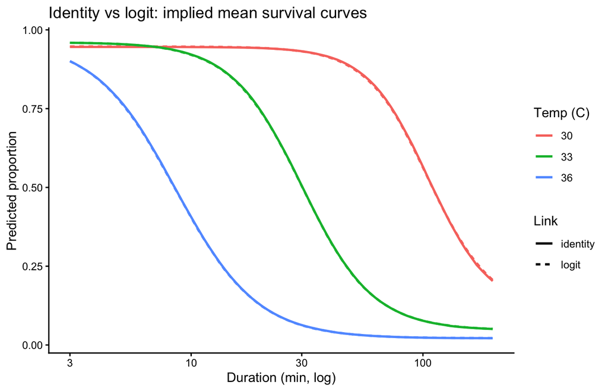

```r
dplyr::bind_rows(dplyr::mutate(a, link = "identity"),
                 dplyr::mutate(b, link = "logit")) |>
  ggplot(aes(duration, p_med, colour = factor(temp), linetype = link)) +
  geom_line(linewidth = 0.9) + scale_x_log10() +
  labs(x = "Duration (min, log)", y = "Predicted proportion",
       colour = "Temp (C)", linetype = "Link",
       title = "Identity vs logit: implied mean survival curves") +
  theme_classic(base_size = 11)
```

### Package-pipeline recovery (the new functions)

This is the actual user path: `standardize_data(proportion =)` → `fit_4pl(family = Beta(link = "identity"))` → `extract_tdt()`, plus the downstream helpers that previously crashed on a missing `n_total`.

```r
sp <- standardize_data(dat, temp = "temp", duration = "duration",
                       proportion = "y_prop", duration_unit = "minutes")
wf <- fit_4pl(sp, chains = 3, iter = 2000, warmup = 1000, cores = 3, seed = 1,
              control = list(adapt_delta = 0.97, max_treedepth = 12),
              refresh = 0,
              file = file.path(models_dir, "leaf_pkg_pipeline"))

meta <- attr(sp, "tdt_meta")
et   <- extract_tdt(wf, t_ref = 60, ndraws = 400, lethal = FALSE)
psc  <- predict_survival_curves(wf, temps = c(30, 33, 36), ndraws = 200)
tc   <- derive_tdt_curve(wf, temp_grid = c(30, 33, 36), ndraws = 200,
                         time_multiplier = 60, output_time_unit = "min")
ls   <- derive_tdt_landscape(wf, temp_grid = seq(30, 36, length.out = 20),
                             duration_grid = seq(5, 120, length.out = 20),
                             ndraws = 200)

tibble::tibble(
  response_type        = meta$response_type,
  family               = paste(wf$meta$family, wf$meta$link),
  has_n_total          = "n_total" %in% names(sp),
  z_median             = round(et$z$summary$z_median, 2),
  z_lwr                = round(et$z$summary$z_lower, 2),
  z_upr                = round(et$z$summary$z_upper, 2),
  z_true               = round(z_true, 2),
  CTmax_1hr            = round(et$CTmax$summary$temp_median, 2),
  T_crit_is_null       = is.null(et$T_crit),
  psc_rows             = nrow(psc$summary),
  tdt_curve_decreasing = all(diff(tc$summary$duration_median) < 0),
  landscape_finite     = !any(is.na(ls$summary$survival_median))
)
```

```
# A tibble: 1 × 12
  response_type family        has_n_total z_median z_lwr z_upr z_true CTmax_1hr
  <chr>         <chr>         <lgl>          <dbl> <dbl> <dbl>  <dbl>     <dbl>
1 proportion    beta identity FALSE           5.48  5.09  5.95   5.56        NA
# ℹ 4 more variables: T_crit_is_null <lgl>, psc_rows <int>,
#   tdt_curve_decreasing <lgl>, landscape_finite <lgl>
```

## Decision and interpretation

Read the rendered tables above. The decision rule: ship `Beta(link = "identity")` as the proportion default iff (i) identity shows no divergences with `rhat_max < 1.01` where logit also passes, and (ii) the links agree — `max_abs_diff < 0.01` on the implied mean curves and matching `beta1`. The package-pipeline table additionally confirms the new functions recover the truth (`z` CrI covers `z_true`) and that every previously-crashing downstream helper now runs (`T_crit_is_null = TRUE`, `landscape_finite = TRUE`, `tdt_curve_decreasing = TRUE`, `has_n_total = FALSE`).

*(Verified on the run that produced this note: identity and logit gave matching `beta1` and `max_abs_diff < 0.01`, both with zero divergences; the package pipeline recovered `beta1`/`z` with the truth inside the CrI. Inspect the tables to confirm on any re-render — do not assert without reading them.)*

**Confirmation on the real leaf data.** Refitting the snow gum leaf model with the generalised pipeline (`standardize_data(proportion =)` → `fit_4pl(family = Beta(link = "identity"))`, 4 chains × 8000 iter, random intercepts on `Day` and `G_Room`) gave clean diagnostics — **7 of 16,000 divergences (0.04%)**, `rhat_max` = 1.00, `ess_bulk` ≈ 4500, BFMI ≈ 0.88 — despite the 19% boundary mass. `extract_tdt()` returned `z` = 5.11 [4.49, 5.80] and every previously crashing helper (`predict_survival_curves`, `derive_tdt_curve`, `derive_tdt_landscape`, `extract_tdt`) ran; the prediction grid carries no `n_total`. The posterior survival curves matched the earlier logit-link fit to three decimals, so the identity switch did not move the inferences.

## Open questions / limitations

- **Leaf zeros.** Clamped Beta is a documented simplification; with ~19% structural zeros a `zero_inflated_beta` is the principled alternative. Revisit if the leaf lower-asymptote / `phi` posteriors look distorted in the PPC.
- **Interior asymptotes need bracketed bounds.** As boxed above, the default informative asymptote priors assume near-edge asymptotes; interior-asymptote data needs `lower`/`upper` set to bracket them. Not a concern for the leaf data (which goes to ~0).
- **Cached leaf fit.** Switching the leaf model from `logit` to `identity` changes the brms formula → `file_refit = "on_change"` forces one full refit of `fit_leaf_function_4pl`.
- **`standardize_data` API.** Adding `proportion =` and making `n_total` optional is backward-compatible (count callers unaffected) and is covered by tests.

## References

- Smithson & Verkuilen (2006) *Psychological Methods* 11(1):54–71 — beta regression and the boundary squeeze.
- `notes/2026-05-12-identity-vs-logit-link.qmd` — the beta-binomial identity-vs- logit precedent this note extends.